# Moje Pasje i Zainteresowania

Mateusz Drąg

## 1. Wstęp - Kim jestem?

Witajcie na mojej prezentacji. Chciałbym opowiedzieć krótko o tym, co mnie interesuje i co robię w wolnym czasie.

**Główne obszary moich zainteresowań:**

- Muzyka (festiwale i koncerty)
- Kinematografia (dobre filmy)
- Gaming (gry strategiczne i RPG)

## 2. Muzyka

**Muzyka towarzyszy mi każdego dnia. Korzystam ze Spotify, ale uwielbiam też muzykę na żywo.**

Muzyka jest dla mnie ważną częścią codziennego życia i sposobem na oderwanie się od rutyny. Największą przyjemność sprawiają mi koncerty i festiwale, gdzie można poczuć energię tłumu i wyjątkową atmosferę wydarzeń na żywo. Cenię różnorodność gatunków oraz możliwość odkrywania nowych artystów.

## 3. Kinematografia

Filmy traktuję jako formę rozrywki, ale także źródło inspiracji i refleksji. Najbardziej interesują mnie produkcje z dobrze napisaną fabułą, wyrazistymi bohaterami i ciekawym przesłaniem. Lubię analizować historie oraz sposób, w jaki film oddziałuje na emocje widza.

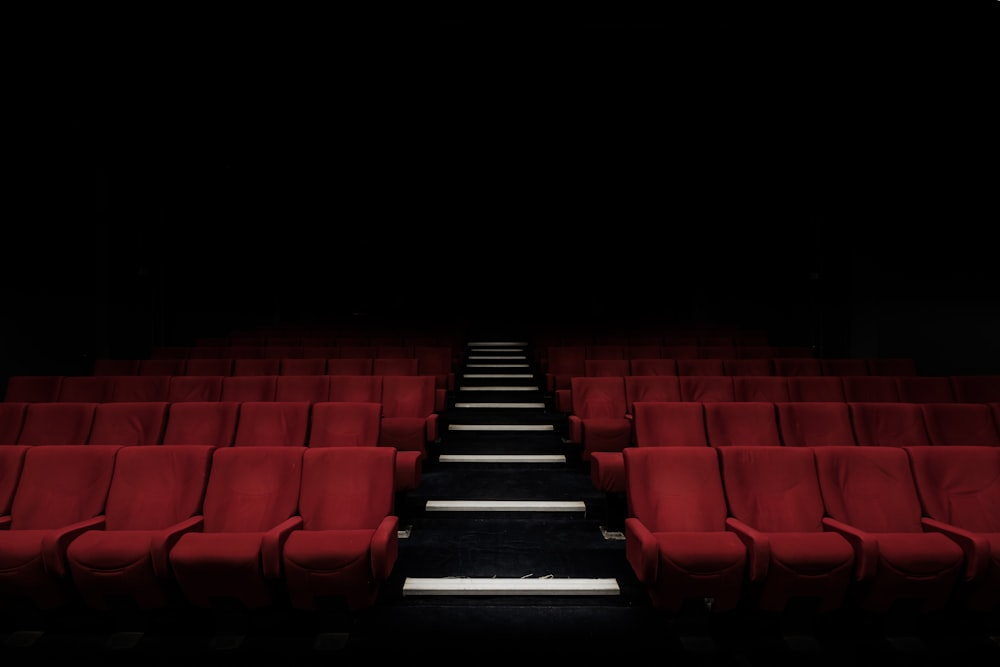

Sala kinowa

## 4. Analiza gustu filmowego

Stworzyłem małe zestawienie moich ocen dla ostatnich 5 filmów, które obejrzałem. Użyłem do tego prostej ramki danych w R.

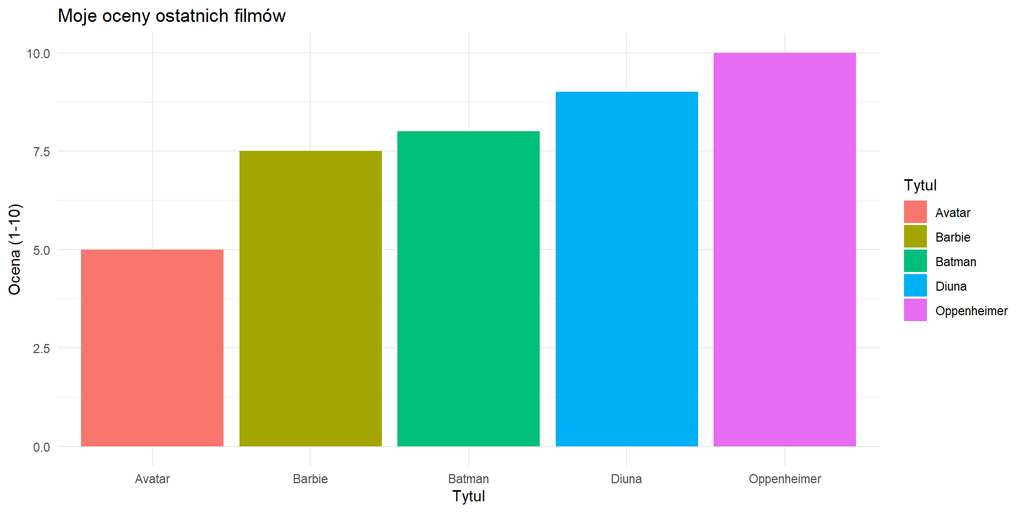

## 5. Gry Wideo

Gry to dla mnie forma interaktywnej opowieści.

- Lubię gry z dobrą fabułą (np. Wiedźmin 3).
- Czasami gram w gry strategiczne, co rozwija logiczne myślenie.
- Interesuję się też rynkiem e-sportowym.

## 6.Czas w grach

Poniżej wykres punktowy, który spokazuje zależność między ceną gry a liczbą godzin, jaką w niej spędziłem.

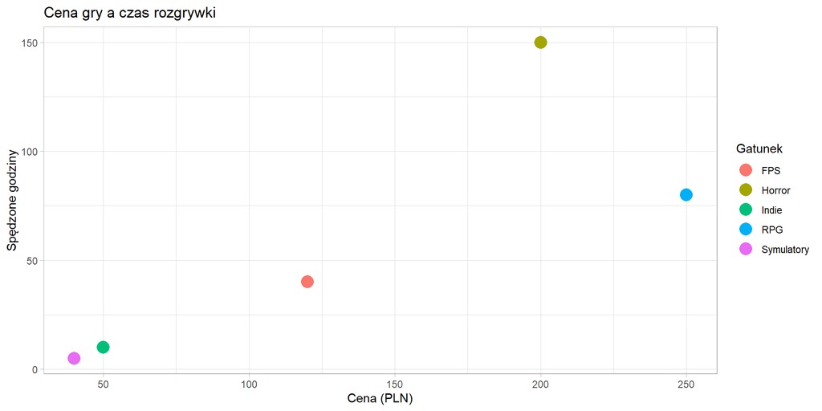

## 7.Koniec

Dziękuję za obejrzenie mojej prezentacji!

Mam nadzieję, że udało mi się pokazać, co lubię robić w wolnym czasie, wykorzystując przy tym umiejętności nabyte na zajęciach z R.